# Accuracy Logistic Regression

Juan M Gonzlez

2024-07-06

```r
data <- read.csv("/Users/jorgevargasmutizabal/Desktop/Frog game statistics/R Analysis Frog/filtered_data.csv")

data <- data %>%
  mutate(
    Player_ID = as.factor(Player_ID),          # Convert to factor
    LexTale = as.numeric(LexTale),              # Convert to numeric
    Game_Version = as.factor(Game_Version),     # Convert to factor
    Game_Level = as.factor(Game_Level),        # Convert to factor
    Phrase_Condition = as.factor(Phrase_Condition), # Convert to factor
    Question_Num = as.numeric(Question_Num),    # Convert to numeric
    Answer = as.numeric(Answer),                 # Convert to factor
    Reaction_Time = as.numeric(Reaction_Time)   # Convert to numeric
  )

# Verify changes
str(data)
```

```
## 'data.frame':    21488 obs. of  9 variables:
##  $ X               : int  1 2 3 4 5 6 7 8 9 10 ...
##  $ Player_ID       : Factor w/ 38 levels "1","2","3","4",..: 1 1 1 1 1 1 1 1 1 1 ...
##  $ LexTale         : num  8 8 8 8 8 8 8 8 8 8 ...
##  $ Game_Version    : Factor w/ 4 levels "1","2","3","4": 1 1 1 1 1 1 1 1 1 1 ...
##  $ Game_Level      : Factor w/ 8 levels "1","2","3","4",..: 1 1 1 1 1 1 1 1 1 1 ...
##  $ Phrase_Condition: Factor w/ 4 levels "1","2","3","4": 1 1 1 1 1 1 1 1 1 1 ...
##  $ Question_Num    : num  0 1 2 3 4 5 6 7 8 9 ...
##  $ Answer          : num  1 1 1 1 1 1 1 1 0 1 ...
##  $ Reaction_Time   : num  1.99 0.8 1.8 0.77 0.82 0.86 0.82 0.85 0.78 1.06 ...
```

# Why Logistic regression?

Logistic regression is a powerful statistical tool used primarily when the outcome you’re studying is binary, like yes/no or success/failure scenarios. It differs from linear regression by predicting probabilities that are constrained between 0 and 1, using a logistic function. This approach provides insights into how likely an event is to occur, offering interpretable results such as odds ratios, which describe how the likelihood of the outcome changes with different predictor variables. Logistic regression is particularly useful because it can handle non-linear relationships, include random effects to account for variability across subjects in studies like surveys or experiments, and is robust against model overfitting through techniques like regularization.

## 0. Accuracy marginalizing over everything

Accounting for variability among participants (participants as a random effect) Oa: ac ~ 1 + (1 | participant)

```r
# Fit a basic logistic mixed-effects model
model0 <- glmer(Answer ~ 1 + (1 | Player_ID), data=data, family=binomial)

summary(model0)
```

```
## Generalized linear mixed model fit by maximum likelihood (Laplace
##   Approximation) [glmerMod]
##  Family: binomial  ( logit )
## Formula: Answer ~ 1 + (1 | Player_ID)
##    Data: data
##
##      AIC      BIC   logLik deviance df.resid
##  19426.2  19442.2  -9711.1  19422.2    21486
##
## Scaled residuals:
##     Min      1Q  Median      3Q     Max
## -3.3308  0.3398  0.4080  0.4852  0.6156
##
## Random effects:
##  Groups    Name        Variance Std.Dev.
##  Player_ID (Intercept) 0.147    0.3835
## Number of obs: 21488, groups:  Player_ID, 38
##
## Fixed effects:
##             Estimate Std. Error z value Pr(>|z|)
## (Intercept)  1.69897    0.06555   25.92   <2e-16 ***
## ---
## Signif. codes:  0 '***' 0.001 '**' 0.01 '*' 0.05 '.' 0.1 ' ' 1
```

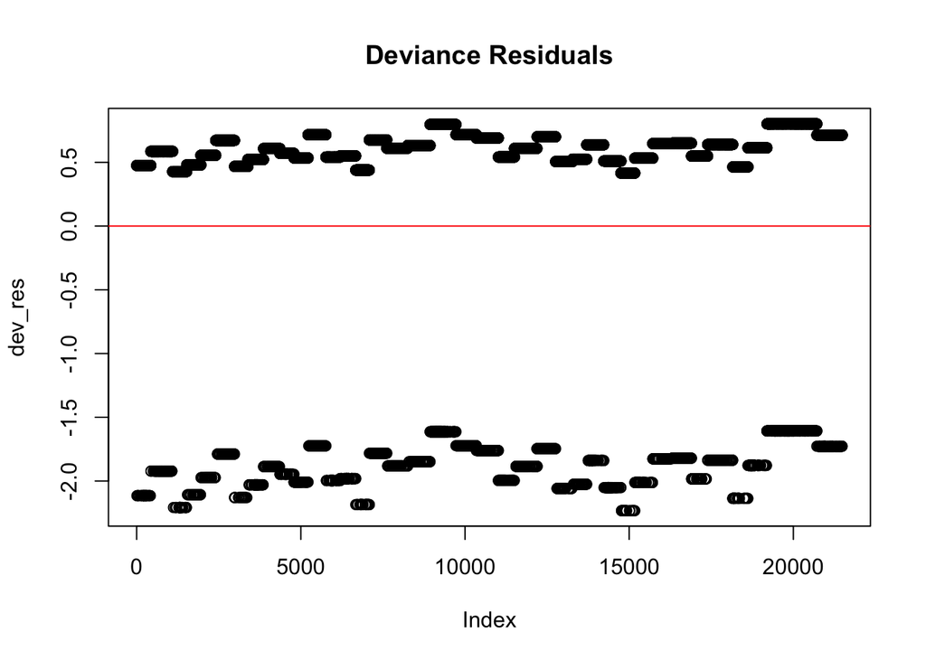

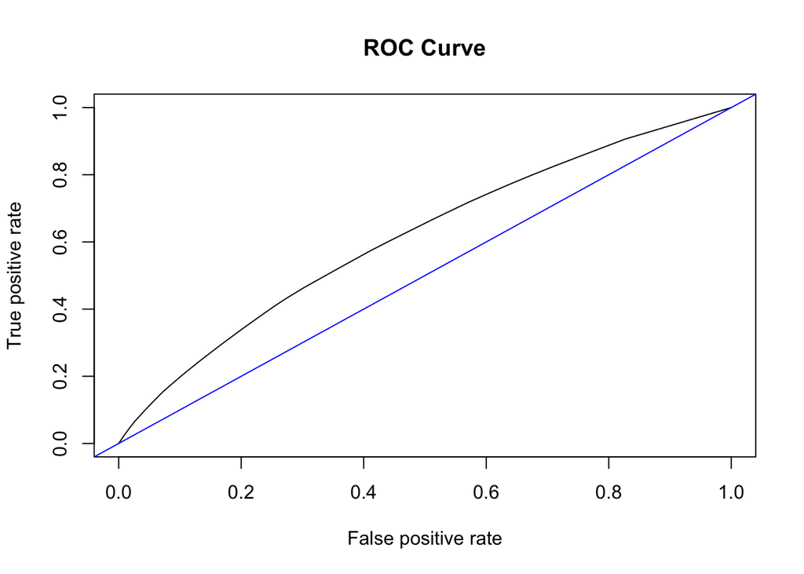

```
## Area Under the Curve (AUC): 0.6125971
```

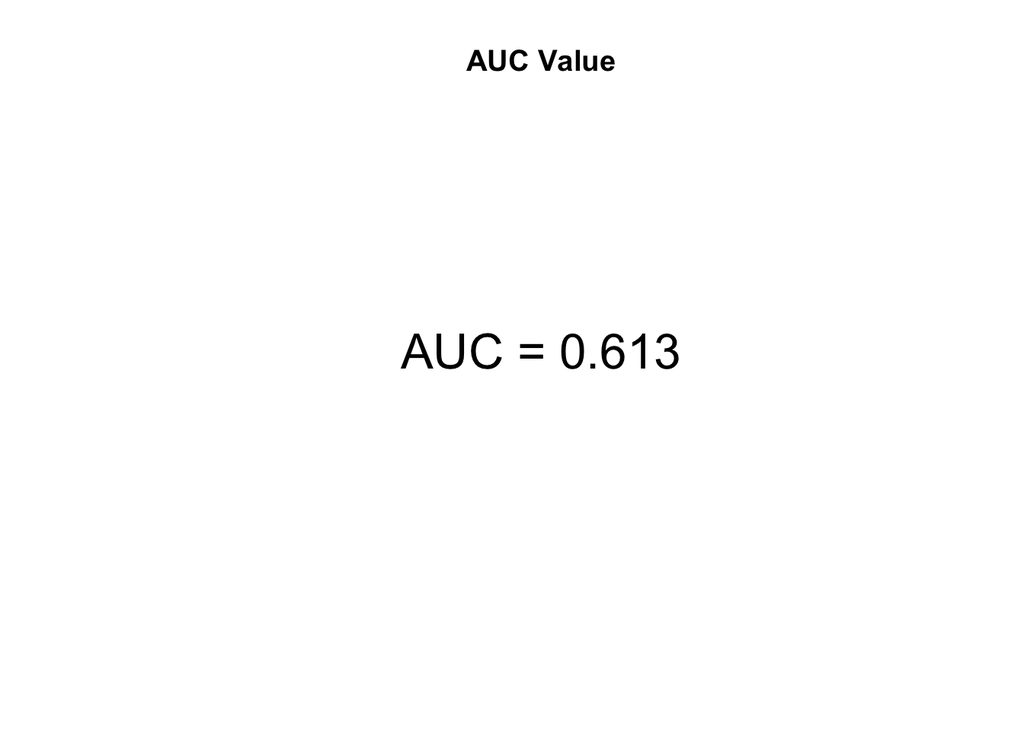

```r
plotModelDiagnostics(model0, data)
```